# Introduction

# Team Jet-lag/Topic:COVID-19 Impact

Coronavirus is a hot topic this year, people around the world are hugely affected by it. As international students, we are facing many difficulties due to coronavirus. It affected our lives in so many ways. And we believed that others have been through the same thing like us.

Thus, we decided to engage in this field and create a website that could help people in this complex situation. We hope that our design could help people gain insights and reduce their stress, informing the public of the effect of COVID-19 on education, transportation, and work. We also want to go further by adding information about where you could get a covid test and which hospital you could go to for help.

## Summary Information

After looking at the data closely and generating aggregate summary of it, we realized how much impact COVID-19 had made to our society. So many people from different ages groups and races are heavily affected by it. For example, hospital treatment among all race and ethnicity is 16%, which is rather low. This may be a sign indicating how compacted hospitals are and the inability of hospitals for taking in all patients in need. Among all race and ethnicity groups, black and non-hispanic people have a hospital treatment rate of 24%, which is the highest among all race and ethnicity groups.

As for the age factors, most of COVID-19 cases are confirmed at the age group between 20 - 29 Years, which takes up about 20% of the total confirmed population. On the other hand, the age group 0 - 9 Years has the smallest percentage of confirmed cases that takes up only about 3%. Thus, we should rise the alter to be aware of the harsh situation and do everything possible to protect ourselves form getting infected, avoiding risky behaviors during this sensitive period of time.

## Table

The original data was downloaded from [*U.S. Government’s open data*](https://catalog.data.gov/dataset/covid-19-case-surveillance-public-use-data). The dataframe’s column names (cdc_report_dt, Race and ethnicity (combined), hosp_yn, death_yn) has been modified to be more human readable. The dataframe was filtered to remove columns that were not used (pos_spec_dt, onset_dt, icu_yn, medcond_yn). The dataframe was sorted in the ascending order of date. The dataframe was sliced to show first 10 rows. The table was included to show used dataset. The table reveals information such as column names that helps understand the dataset better.

| cdc_report_date | current_status | sex | age_group | race_ethnicity_combined | hospitalized | death |
| --- | --- | --- | --- | --- | --- | --- |
| 2020/01/01 | Probable Case | Male | 60 - 69 Years | White, Non-Hispanic | No | No |
| 2020/01/01 | Laboratory-confirmed case | Male | 40 - 49 Years | Black, Non-Hispanic | Yes | No |
| 2020/01/01 | Laboratory-confirmed case | Female | 30 - 39 Years | White, Non-Hispanic | No | No |
| 2020/01/01 | Probable Case | Male | 40 - 49 Years | White, Non-Hispanic | Unknown | Unknown |
| 2020/01/01 | Laboratory-confirmed case | Male | 70 - 79 Years | Multiple/Other, Non-Hispanic | No | No |
| 2020/01/01 | Laboratory-confirmed case | Male | 30 - 39 Years | Asian, Non-Hispanic | Unknown | No |
| 2020/01/01 | Laboratory-confirmed case | Female | 30 - 39 Years | White, Non-Hispanic | No | No |
| 2020/01/01 | Probable Case | Female | 50 - 59 Years | Unknown | No | No |
| 2020/01/01 | Laboratory-confirmed case | Female | 50 - 59 Years | White, Non-Hispanic | No | No |
| 2020/01/01 | Laboratory-confirmed case | Female | 50 - 59 Years | White, Non-Hispanic | Unknown | No |

The dataframe was grouped and summarized by current status. The table was included to show differences between laboratory confirmed/probable cases. The table reveals number of laboratory confirmed/probable cases.

| current_status | num_current_status |
| --- | --- |
| Laboratory-confirmed case | 4322724 |
| Probable Case | 158338 |

## Chart 1

Due to the sudden mass out broke of the pandemic, hospital resources became preciouses and not everyone had the opportunity to be treated by hospitals. We want see whether there is a difference in hospital treatment rate among people from different race and ethnicity groups by looking into the general hospital treatment rate of COVID-19 in the U.S. and compare it with the hospital treatment rates for each specific race and ethnicity group.

The chart showing the hospital treatment rate among different race and ethnicity is displayed below. (People who do not have a hospital record and people who have a unknown race and ethnicity record are filtered out from the data.)

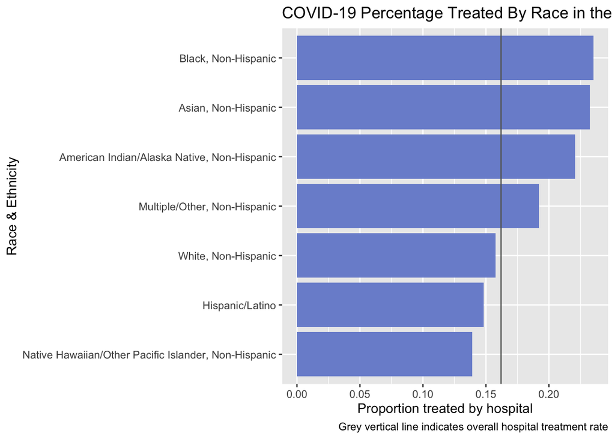

According to the chart, we can see that the over all hospital treatment among all race and ethnicity is 16%, which is rather low. This may be a sign indicating how compacted hospitals are and the inability of hospitals for taking in all patients in need. Among all race and ethnicity groups, black and non-hispanic people have a hospital treatment rate of 24%, which is the highest among all race and ethnicity groups. The race and ethnicity that have the lowest hospital treatment rate is Native Hawaiian/Other Pacific Islander and non-hispanic people, 14%. Possible explanation of these differences may be variation in ability to pay for hospital treatment, severity of illness, and the willingness to seek hospital treatment among these groups.

## Chart 2

Since so many people have been unfortunately confirmed to be the carrier of COVID-19, the public went into panic at the beginning of this chaos. Numerous people are still wondering what the age group of people COVID-19 normally targets at, thus we hope to generate a chart to display the statistical information about the confirmed-cases age group, informing the public an potential correlation between age and the possibility of getting COVID-19.

Below is a chart showing the percentage of confirmed cases by age group and gender:

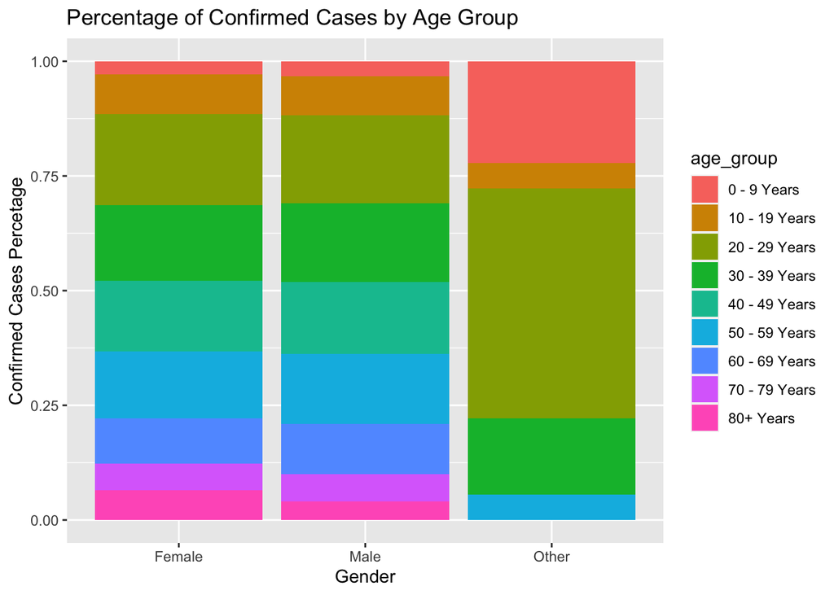

## Chart 3

Covid-19 is getting very serious in the United States, but fortunately, the death rate for this pandemic is relatively lower than another serious pandemic. But what kind of group has a higher mortality rate? Is there any connection between gender and mortality rates or age and mortality rates? Thus, we would like to use this graph to find out how gender influences the mortality rates of people in each age group.

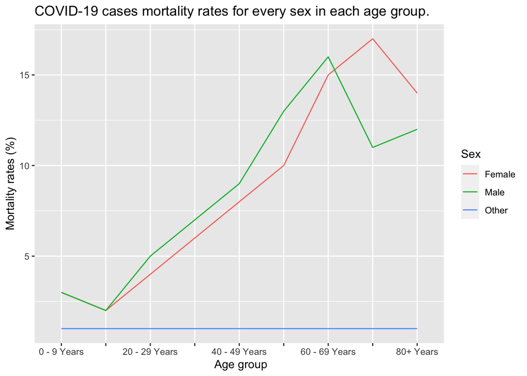